# STAT380- Homework 6

Vince Trost - 958112459

3/27/2017

# (1) State College temperature data (GHCN)

We now return to the State College temperature data set from a previous homework. Read it in again from http://www.stat.psu.edu/~mharan/380/data/tempGHCN/DailyTempSCE20022016.csv As you will recall, this data set has daily temperature data for State College, PA. Now that you know a lot more about string manipulation, I would like you to carry out the exercise I asked you to think about on that homework. Specifically, write code to create a new data set using daily mean temperatures and translate it into monthly temperatures that is in the following format, with three columns: Month Year AverageTemp Months should be 1-12 for January-December.

Once you have this data set ready plot the monthly average temperature over the entire length of the data set. That is, on the x-axis plot the months (numbered 1, 2, 3…. 12, 13, 14,…), while on the y-axis plot the monthly averages.

Let’s re-familiarize ourselves with the data. First I’m going to load it in and then examine the structure

```r
temp=read.table("http://www.stat.psu.edu/~mharan/380/data/tempGHCN/DailyTempSCE20022016.csv", header=TRUE,sep=",")
str(temp)
```

```
## 'data.frame':    5478 obs. of  21 variables:
##  $ STATION              : Factor w/ 1 level "GHCND:USC00368449": 1 1 1 1 1 1 1 1 1 1 ...
##  $ STATION_NAME         : Factor w/ 1 level "STATE COLLEGE PA US": 1 1 1 1 1 1 1 1 1 1 ...
##  $ ELEVATION            : num  357 357 357 357 357 ...
##  $ LATITUDE             : num  40.8 40.8 40.8 40.8 40.8 40.8 40.8 40.8 40.8 40.8 ...
##  $ LONGITUDE            : num  -77.9 -77.9 -77.9 -77.9 -77.9 ...
##  $ DATE                 : int  20020118 20020119 20020120 20020121 20020122 20020123 20020124 20020125 20020126 20020127 ...
##  $ TMAX                 : int  40 32 28 34 39 48 49 52 44 53 ...
##  $ Measurement.Flag     : logi  NA NA NA NA NA NA ...
##  $ Quality.Flag         : Factor w/ 2 levels " ","I": 1 1 1 1 1 1 1 1 1 1 ...
##  $ Source.Flag          : Factor w/ 5 levels " ","0","7","H",..: 2 2 2 2 2 2 2 2 2 2 ...
##  $ Time.of.Observation  : int  700 700 700 700 700 700 700 700 700 700 ...
##  $ TMIN                 : int  25 24 18 16 30 31 42 29 29 29 ...
##  $ Measurement.Flag.1   : logi  NA NA NA NA NA NA ...
##  $ Quality.Flag.1       : logi  NA NA NA NA NA NA ...
##  $ Source.Flag.1        : Factor w/ 5 levels " ","0","7","H",..: 2 2 2 2 2 2 2 2 2 2 ...
##  $ Time.of.Observation.1: int  700 700 700 700 700 700 700 700 700 700 ...
##  $ TOBS                 : int  25 25 18 31 31 44 44 29 37 36 ...
##  $ Measurement.Flag.2   : logi  NA NA NA NA NA NA ...
##  $ Quality.Flag.2       : Factor w/ 2 levels " ","I": 1 1 1 1 1 1 1 1 1 1 ...
##  $ Source.Flag.2        : Factor w/ 4 levels "0","7","H","K": 1 1 1 1 1 1 1 1 1 1 ...
##  $ Time.of.Observation.2: int  700 700 700 700 700 700 700 700 700 700 ...
```

The cleaning of this data from last homework is in a hidden code chunk. The cleaned data is put into a data frame called `tempSCE`.

Improving upon what was completed back in homework 2:

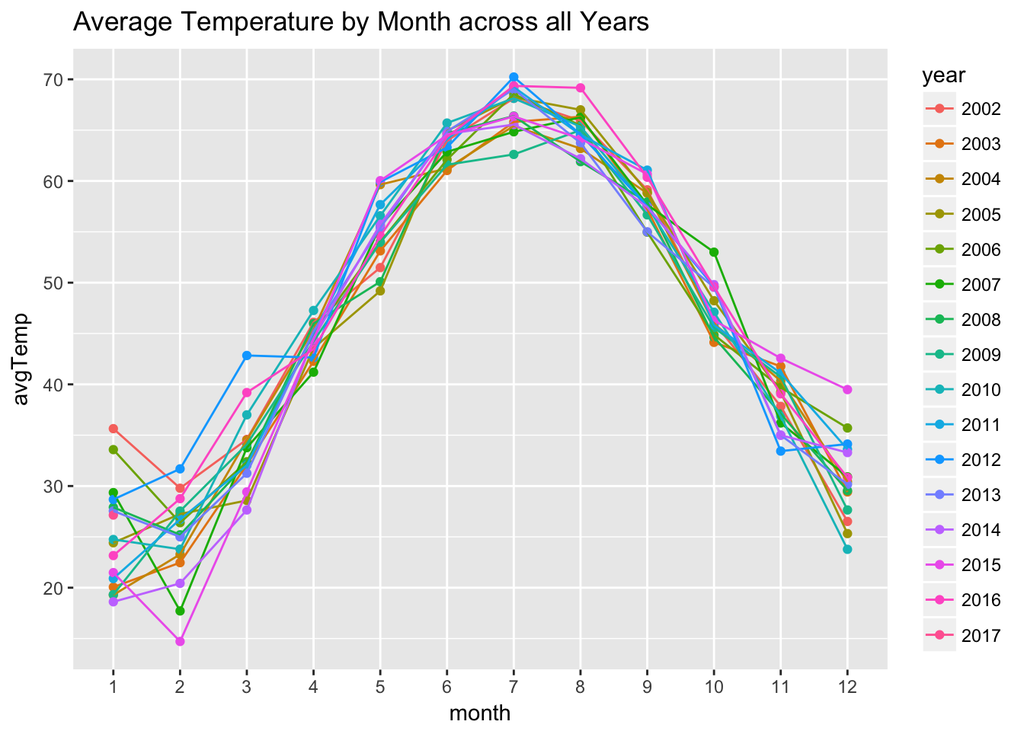

```r
mavgs <- tempSCE %>%
  group_by(lubridate::month(date), lubridate::year(date)) %>%
  summarise(mean(tobs))
names(mavgs) = c("month", "year", "avgTemp")
mavgs$year = as.factor(mavgs$year)
mavgs$month = as.factor(mavgs$month)
ggplot(mavgs, aes(x=month, y=avgTemp, color = year, group = year)) + geom_point() + geom_line() + ggtitle("Average Temperature by Month across all Years")
```

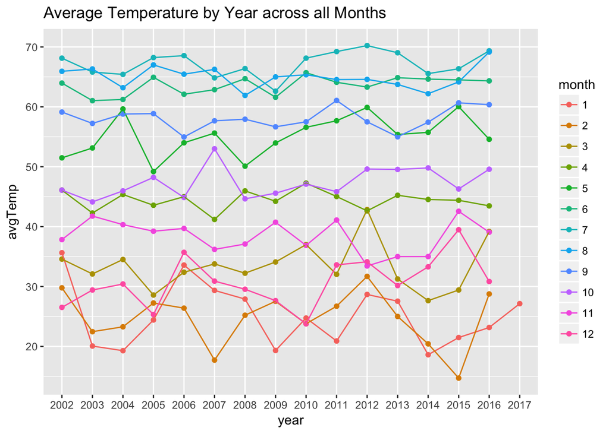

```r
ggplot(mavgs, aes(x=year, y=avgTemp, color = month, group = month)) + geom_point() + geom_line() + ggtitle("Average Temperature by Year across all Months")
```

These two figures complement each other nicely in demonstrating more variability in the winter months across the years as opposed to the summer months that don’t seem to change as much.

# (2) Twitter data

We will use a small sample of the tweets that you will use later. Load them into your session with:

```r
load(url("http://sites.stat.psu.edu/~mharan/380/data/testTweets.rda"))
```

Explore the data frame. How many variables does it have, what’s the class of each, and how many tweets are included?

```r
str(testTweets)
```

```
## 'data.frame':    5 obs. of  3 variables:
##  $ Ttext: chr  "VOTER REGISTRATION DEADLINES TODAY. You can register now at: https://t.co/HfihPEA3Sp and get out to& https://t.co/LlFdF0DRX4" "RT @mike_pence: Congrats to my running mate @realDonaldTrump on a big debate win! Proud to stand with you as we #MAGA." "RT @TeamTrump: It\031s US vs. the…
##  $ Tdate: chr  "Tue Oct 11 20:56:33 +0000 2016" "Mon Oct 10 03:01:22 +0000 2016" "Mon Oct 10 02:41:32 +0000 2016" "Mon Oct 10 02:24:29 +0000 2016" ...
##  $ Tdev : chr  "<a href=\"http://twitter.com/download/iphone\" rel=\"nofollow\">Twitter for iPhone</a>" "<a href=\"http://twitter.com/download/iphone\" rel=\"nofollow\">Twitter for iPhone</a>" "<a href=\"http://twitter.com\" rel=\"nofollow\">Twitter Web Client</a>" "<a href=\"http://twitter.com/d…
```

### Retweets

The text of the tweet is in the variable Ttext in the data frame. Some of these tweets are retweets. You can tell that they are retweets because the begin with an RT. Create a logical vector that is TRUE if the tweet is a retweet. Call the vector `RT`:

```r
RT <- grepl("^RT", testTweets$Ttext)
```

### When the tweet was sent

We are interested in the hour of the day that the tweet was sent. The day, hour, minute, second, and year are provided in `Tdate`.

Use regular expressions to extract the hour of the day that the tweet was sent. Make sure that you save the hour in a numeric vector called `hr`.

```r
#I'm going to need more than one command to do this
a <- sapply(testTweets$Tdate, function(x) sub(":.*", "", x))
a
```

```
## Tue Oct 11 20:56:33 +0000 2016 Mon Oct 10 03:01:22 +0000 2016
##                "Tue Oct 11 20"                "Mon Oct 10 03"
## Mon Oct 10 02:41:32 +0000 2016 Mon Oct 10 02:24:29 +0000 2016
##                "Mon Oct 10 02"                "Mon Oct 10 02"
## Sun Oct 09 14:05:17 +0000 2016
##                "Sun Oct 09 14"
```

```r
b <- sapply(a, function(x) strsplit(x[1], " "))
b
```

```
## $`Tue Oct 11 20:56:33 +0000 2016`
## [1] "Tue" "Oct" "11"  "20"
##
## $`Mon Oct 10 03:01:22 +0000 2016`
## [1] "Mon" "Oct" "10"  "03"
##
## $`Mon Oct 10 02:41:32 +0000 2016`
## [1] "Mon" "Oct" "10"  "02"
##
## $`Mon Oct 10 02:24:29 +0000 2016`
## [1] "Mon" "Oct" "10"  "02"
##
## $`Sun Oct 09 14:05:17 +0000 2016`
## [1] "Sun" "Oct" "09"  "14"
```

```r
hr <- NULL
for(i in 1:length(b)){
  hr <- append(hr, b[[i]][4])
}
hr
```

```
## [1] "20" "03" "02" "02" "14"
```

### Hash Tags

Can you find which tweets contain a hashtag? Hashtags begin with #, and do not include punctuation or blanks. Create a logical vector called aHash that is TRUE if a tweet contains 1 or more hashtags. Be sure that it doesn’t consider a “#” on its own as a hash tag. Call this logical vector `anyHash`.

```r
anyHash <- grepl("#", testTweets$Ttext)
anyHash
```

```
## [1] FALSE  TRUE  TRUE  TRUE FALSE
```

Use `gregexpr` to find the starting and ending point of the hash tags in the tweets that have a hash tag. Check that you correctly identify the starting point and length of the match. For example, one tweet contains “… #MAGA. …” and you do not want to include the period as part of the tag. Also, be sure that your call finds all of the hashtags present in the tweet (some tweets have 2 or 3). Save this information in `hashLocs`.

```r
testTweets$Ttext
```

```
## [1] "VOTER REGISTRATION DEADLINES TODAY. You can register now at: https://t.co/HfihPEA3Sp and get out to& https://t.co/LlFdF0DRX4"
## [2] "RT @mike_pence: Congrats to my running mate @realDonaldTrump on a big debate win! Proud to stand with you as we #MAGA."
## [3] "RT @TeamTrump: It\031s US vs. them! @realDonaldTrump will fight for you! #BigLeagueTruth #Debates"
## [4] "RT @DanScavino: WE LOVE OUR DEPLORABLES!!!\n#TrumpTrain #Debates2016 https://t.co/2Nt9ID3tV7"
## [5] "\"@HenryLeledog: @realDonaldTrump This Black Democrat is on the \"TRUMP TRAIN\"!!\""
```

```r
hashLocs = gregexpr("#[^[:punct:]]+", testTweets$Ttext)
hashLocs
```

```
## [[1]]
## [1] -1
## attr(,"match.length")
## [1] -1
## attr(,"useBytes")
## [1] TRUE
##
## [[2]]
## [1] 113
## attr(,"match.length")
## [1] 5
## attr(,"useBytes")
## [1] TRUE
##
## [[3]]
## [1] 71 87
## attr(,"match.length")
## [1] 16  8
## attr(,"useBytes")
## [1] TRUE
##
## [[4]]
## [1] 44 56
## attr(,"match.length")
## [1] 12 18
## attr(,"useBytes")
## [1] TRUE
##
## [[5]]
## [1] -1
## attr(,"match.length")
## [1] -1
## attr(,"useBytes")
## [1] TRUE
```

```r
hashtagList =
  mapply(function(x, sta) {
    substr(rep(x, length(sta)),
           start = sta,
           stop = sta + attributes(sta)$match.length - 1)
  },
         x = testTweets$Ttext,
         sta = hashLocs)
names(hashtagList) = NULL
hashtagList
```

```
## [[1]]
## [1] ""
##
## [[2]]
## [1] "#MAGA"
##
## [[3]]
## [1] "#BigLeagueTruth " "#Debates"
##
## [[4]]
## [1] "#TrumpTrain "       "#Debates2016 https"
##
## [[5]]
## [1] ""
```

### (3) Reading in real Twitter data

This problem gets you started with extracting features from a sample of tweets from @RealDonaldTrump. These tweets cover the period from 21 Jan through 11 Oct 2016. In addition to the tweet itself, twitter also provides meta information about the tweet. This information includes the date of the tweet and the type of device on which the tweet was made.

There is a conjecture that @RealDonaldTrump tweets from an Android are different from tweets from an iPhone. The goal is to investigate this conjecture. And some say that Donald Trump himself uses only one of these devices.

To study this conjecture, we will later create the following variables from the tweets and their meta data:

- device on which the tweet was sent – dev, factor with levels, Android, iPhone, and Other.
- number of characters in the tweet – numC, numeric
- number of words in the treat (ok to count a url as a word) – numW, numeric
- indicator for whether the tweet begins with a quotation mark – beginQ, factor
- indicator for whether the tweet begins with RT (meaning a retweet) – rt, factor
- indicator for whether the tweet contains a link – link, factor
- number of hashtags in the tweet – numHT, numeric
- number of twitter usernames in the tweet – numAt, numeric
- hour of the day the tweet was sent – hr, numeric

In addition, we take the 5 most popular hashtags and the 5 most popular usernames and create factors for each that indicate whether that hashtag or username appears in the tweet. I have provided these for you in a data frame at “http://sites.stat.psu.edu/~mharan/380/data/topHashAndAt.rda”

### The Data

The data are in a json file and can be read into R with the `RJSONIO` package. After you install and load the package, read in the data with

```r
library(RJSONIO)
tweetLines = readLines(url("http://sites.stat.psu.edu/~mharan/380/data/realDonaldTrump.json"))
tweetList = fromJSON(paste(tweetLines, collapse = " "))
names(tweetList) = NULL
tweetList[[1]]
```

[output not shown]

[output cut: 164 more lines]

[output not shown]

Explore the list structure. Examine the top of each element to find where the tweet text, time, and device appear. Extract the text of the tweets and place them in a character vector called `tweets`.

```r
tweets <- NULL
for(i in 1:length(tweetList)){
  tweets <- append(tweets, tweetList[[i]]$text)
}
```